# Конфигурирование VLAN

Лабораторная работа №5

Гафоров Нурмухаммад

Российский университет дружбы народов, Москва, Россия

09.03.2026

# Цель работы

## Цель

- Получить навыки настройки VLAN
- Изучить VTP и trunk-порты
- Проверить передачу ICMP в сети

# Ход выполнения

## Построение топологии сети

- Создана корпоративная сеть в Packet Tracer
- Использованы коммутаторы, ПК и серверы
- Сеть имеет иерархическую структуру

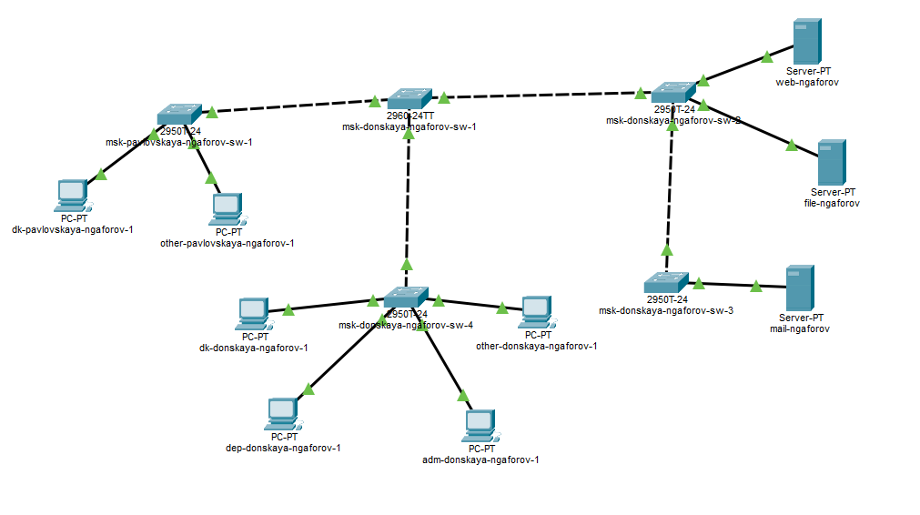

Топология сети

## Настройка IP-адресации

- На ПК выбран режим **Static**
- Заданы IP-адрес, маска и шлюз
- Адреса распределены по подсетям VLAN

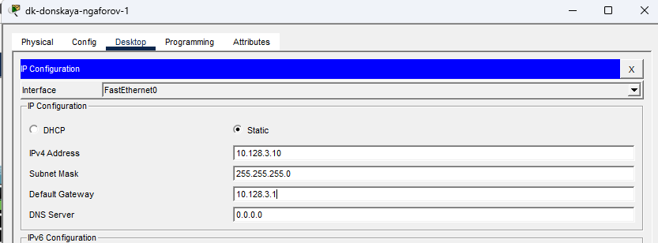

Настройка IP на ПК

## Примеры назначенных адресов

- **10.128.3.10/24** — сегмент dk
- **10.128.4.10/24** — сегмент departments
- **10.128.5.10/24** — сегмент adm
- **10.128.6.10/24** — сегмент other

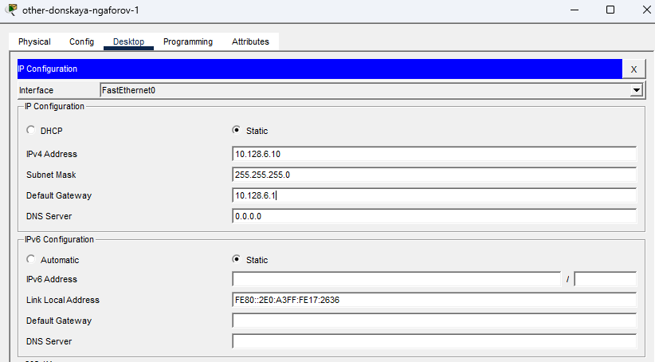

Статическая адресация

## Настройка VTP-сервера

- **msk-donskaya-ngaforov-sw-1** переведён в режим server
- Заданы домен **donskaya** и пароль **cisco**
- Созданы VLAN и их имена

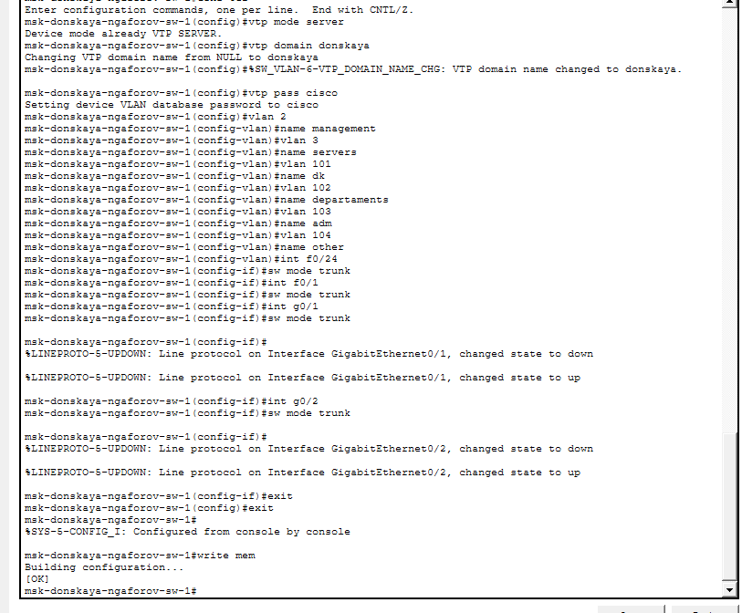

VTP-сервер и VLAN

## Созданные VLAN

- **VLAN 2** — management
- **VLAN 3** — servers
- **VLAN 101–104** — пользовательские сегменты
- База VLAN хранится на сервере VTP

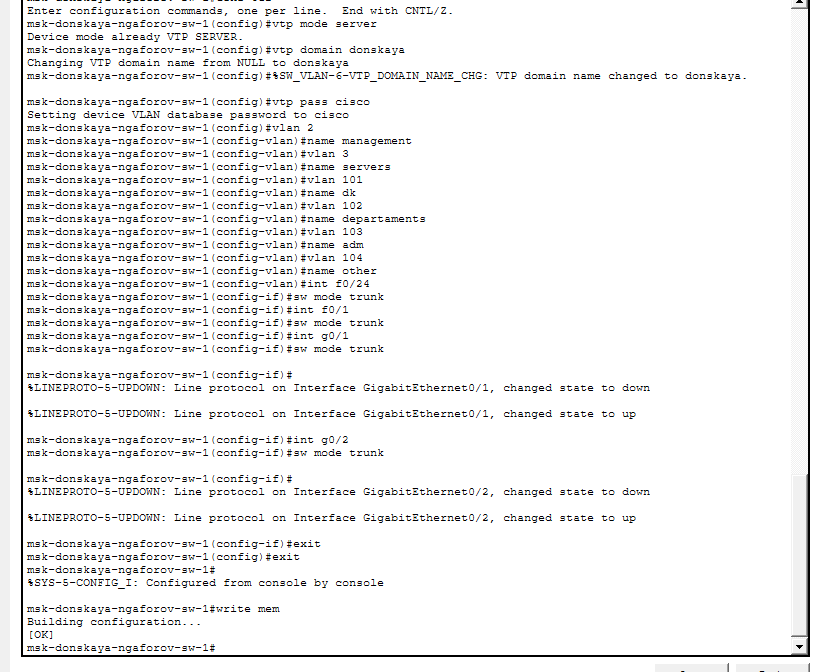

Создание VLAN

## Настройка trunk-портов

- Межкоммутаторные линии переведены в **trunk**
- Trunk передаёт трафик нескольких VLAN
- Использованы интерфейсы **g0/1**, **g0/2**, **f0/24**

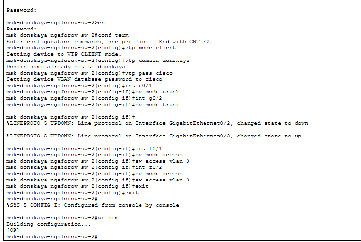

Trunk-порты на коммутаторе

## Настройка VTP-клиентов

- Остальные коммутаторы переведены в режим client
- Указаны тот же домен и пароль
- VLAN получены автоматически от сервера

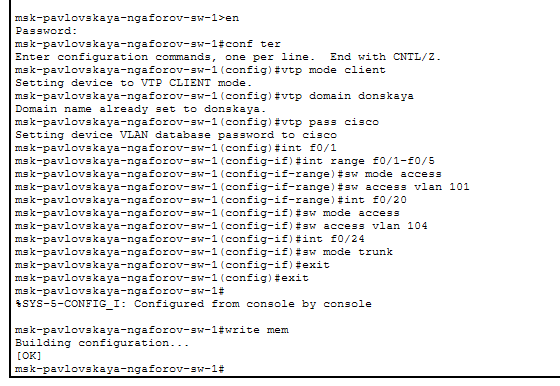

VTP-клиент

## Назначение портов VLAN

- Пользовательские порты настроены как **access**
- Порты распределены по VLAN 101–104
- Серверные порты отнесены к **VLAN 3**

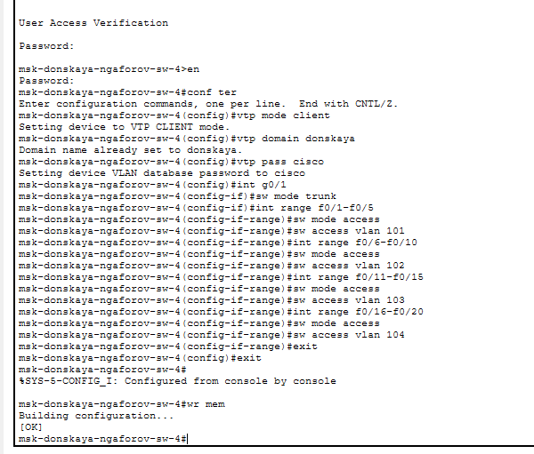

Назначение VLAN на порты

## Проверка связности в одном VLAN

- Выполнен **ping** между узлами одной VLAN
- Все пакеты доставлены успешно
- Потерь при передаче нет

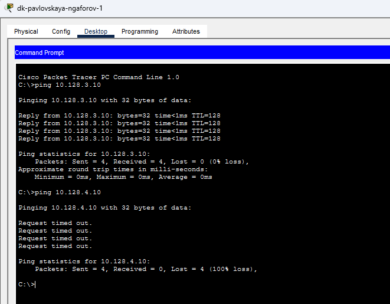

Успешный ping

## Проверка между разными VLAN

- Выполнен **ping** между разными VLAN
- Получено сообщение **Request timed out**
- Без маршрутизации доступ отсутствует

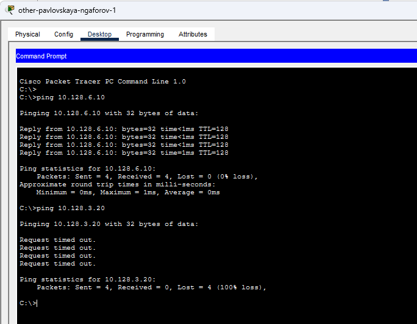

Недоступность между VLAN

## Режим симуляции

- Изучено движение ICMP-пакета по сети
- Отслежен путь через коммутаторы
- Просмотрен список событий передачи

[figure not shown]

Simulation Mode

## Структура передаваемого пакета

- Рассмотрен кадр **Ethernet II**
- Изучен заголовок **IPv4**
- Проанализировано сообщение **ICMP**

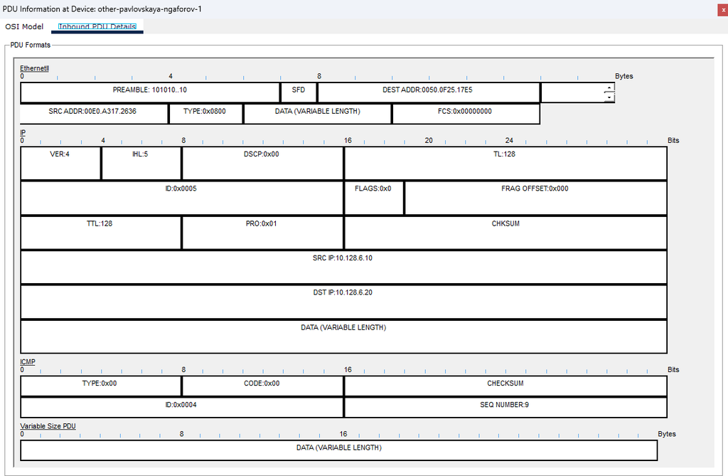

Структура ICMP-пакета

## Ethernet, IP и ICMP

- Ethernet содержит MAC-адреса источника и получателя
- IP задаёт адресацию и TTL
- ICMP используется для диагностики сети

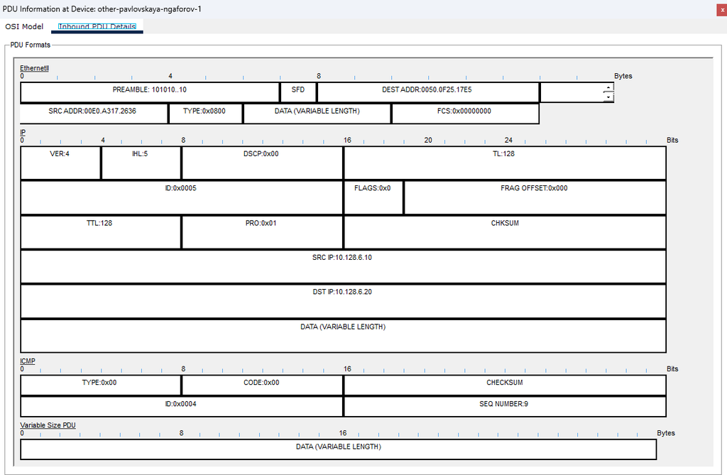

PDU Information

# Итог

## Вывод

- Выполнена настройка VLAN, VTP и trunk
- Проверена изоляция разных VLAN
- Изучена передача ICMP в Simulation
- Закреплены навыки настройки коммутируемой сети